# Magnetic circuits

Some points to understand magnetic circuits

```
- Residual flux density and coercive force
- Hysteresis Loop
- Hysteresis loss
- Eddy currents
```

So we have seen that the current in a coil of wire wrapped around a core produces a magnetic flux in the core $\Phi$

[figure not shown]

*Both circuits have same rules so same analogy applies*

| Electric Circuit | Magnetic Circuit |
| --- | --- |
| **Ohm's law** | **Analogous to Ohm's law** |
| $V = I\cdot R$ | $\mathcal{F} = \Phi \mathcal{R}$ |
| $V$ = electromotive force (emf) $I$ = current $R$ = resistance | $\mathcal{F}$ = magnetomotive force (mmf) $(NI)$ $\Phi$ = magnetic flux $\mathcal{R}$ = reluctance |

### Energy Losses in a Ferromagnetic core

The main losses in electromagnetic processes are:

1. Hysteresis loss
2. Eddy current loss

In this lecture we will understand the losses, and in later lectures we will investigate how to model them

#### Faraday's law of electromagnetic induction

Faradays law of electromagentic induction states the fundamental relationship between voltage and flux in a circuit

1. If the flux linking a loop (or turn) varies as a function of time, a voltage is induced between its terminals
2. The value of the induced voltage is proportional to the rate of change of flux

Described by

$$ emf = N\frac{\Delta \Phi}{\Delta t} $$ where
emf = electromotove force -induced voltage [V]
N = Number of turns in the coil
$\Delta \Phi$ = change of flux inside the coil [Wb]
$\Delta t$ = time interval during which the flux changes [s]

[Electromagnetic Induction](https://nationalmaglab.org/magnet-academy/watch-play/interactive-tutorials/electromagnetic-induction/)

#### Voltage induced in a conductor

Easier to calculate length of conductors than whenever a concuctor cuts a magnetic field

$$ emf = Blv $$ where
emf = electromotive force -induced voltage [V]
B = flux density [T]
l = active length of the conductor in the magnetic field [m]
v = relative speed of the conductor [m/s]

#### Lorentz force on conductor

$$ F = BlI $$

where  
emf = electromotove force -induced voltage [V]  
B = flux density [T]  
l = active length of the conductor [m]  
I = current in the conductor [A]

[Lorentz Force](https://nationalmaglab.org/magnet-academy/watch-play/interactive-tutorials/lorentz-force)

#### Direction of the force acting on a straight conductor

A current carrying conductor in a magnetic field will assert a force.

The force is given by how the magnetic field lines aligns itself

Magnetic field lines goes out of the North pole and into the South pole.

[figure not shown]

*Magnetic force between North and South pole in a magnet*

#### Filed of current-carrying conductor

A cross gives the direction of current going into the page, known as dot convention. According to Maxwells right hand rule (corkscrew) the circular lines of force are given in.

[figure not shown]

*The right hand rule when current goes into the page by dot convention*

#### Combined fields

Two magnetic fields excells a force

[figure not shown]

*The magnetic fields combined*

#### Force

Yet magnetic field lines will never cross each other, but align up in such a manner that the magnetic field above the conductor will add, and the magnetic field beneth the conductor will cancel each other out, so that in the end there is more magnetic field lines above.

It is shown how the force excelled on the conductor is going down.

[figure not shown]

*The sum of the magnetic fields excells a Lorents force*

[Inductive Reactance](https://nationalmaglab.org/magnet-academy/watch-play/interactive-tutorials/inductive-reactance/)

#### Eddy currents

Faraday law explains the eddy current losses. When a time-changing flux induces a voltage within a ferromagnetic core in just the same manner as it would in a wire wrapped around that that core.

These voltages cause swirls of currents within the core, much like eddies seen at the edges of a river. It is the shape that gives name to eddy currents

[figure not shown]

*Eddy currents opposing the flux due to Lenz law*

A solid plate behaves like a huge number of conducting loops packed together. The ac flux passes through a solid metal plate. It is basically equivalent to a densely packed set of rectangular conductors touching each other.

[figure not shown]

Lenz law

IMAGE CREDITS courtesy of Wikimedia Commons.

https://commons.wikimedia.org/wiki/Category:Lenz%27s_law#/media/File:Lenzs-law-cylindrical-magnet-entering-ring.png

[figure not shown]

*Current-loop inducing eddy currents*

The flux is assumed to be increasing. Lenz’s law, is causing the eddy currents to flow in such a way as to oppose the increasing flux.

To understand the effect of eddy currents the plate can be modeled as an infinite number of neighboring current loops.

[figure not shown]

*The effect of several eddy-currents*

An ac flux that links a rectangular-shaped conductor. According to Faraday’s law, an ac voltage E1 is induced across its terminals.

#### Residual flux density and coercive force

Starting from zero I increase, there is an increase in H and B, traced in curve 0-a. The flux density reaches a value $B_m$ for a magnetic field strength $H_m$.

If the current is reduced to zero the flux density traces curve a-b. The magnetic domains that were lined up under the influence of $H_m$ retain their original orientation.

When H is reduced to zero, a substantial flux density remains: The residual flux density or residual induction $B_r$.

The magnetic field strength required to reduce the flux to zero is called coercive force $H_c$. This requires energy that is dissipated as heat in the material

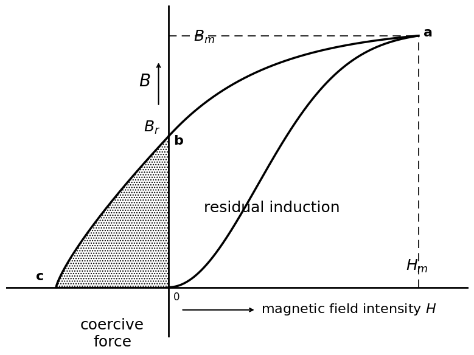

#### Hysteresis Loop

[Alternating Current](https://nationalmaglab.org/magnet-academy/watch-play/interactive-tutorials/alternating-current/)

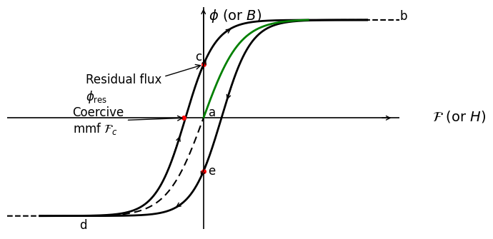

#### Hysteresis loss

The magnetic material absorbs energy during each cycle and this energy is dissipated as heat.

To reduce hysteresis losses one can select magnetic materials that have a narrow hysteresis loop, such as the grain-oriented silicon steel used in the cores of alternating-current transformers

### Significance:

The hysteresis loop provides valuable information about the magnetic properties of a material, including its saturation magnetization, retentivity, and coercivity. It helps engineers select appropriate materials for various applications, such as transformers, motors, and magnetic storage devices. The area enclosed by the hysteresis loop represents the energy loss per cycle due to hysteresis, which is important in applications where energy efficiency is critical.